# 19BCE1717 Lab FAT

##### 4) Using box plots observe the liklihood card being approved based on the ownership and months of living in a area.

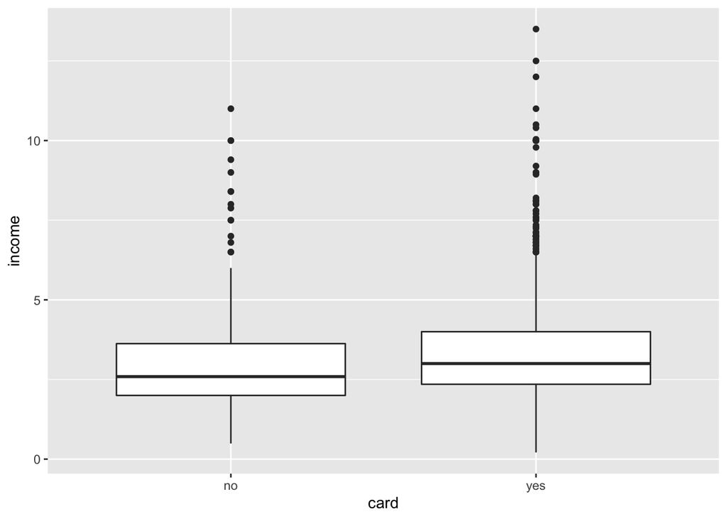

```r
ggplot(data=data, aes(x=card, y=income))+geom_boxplot()
```

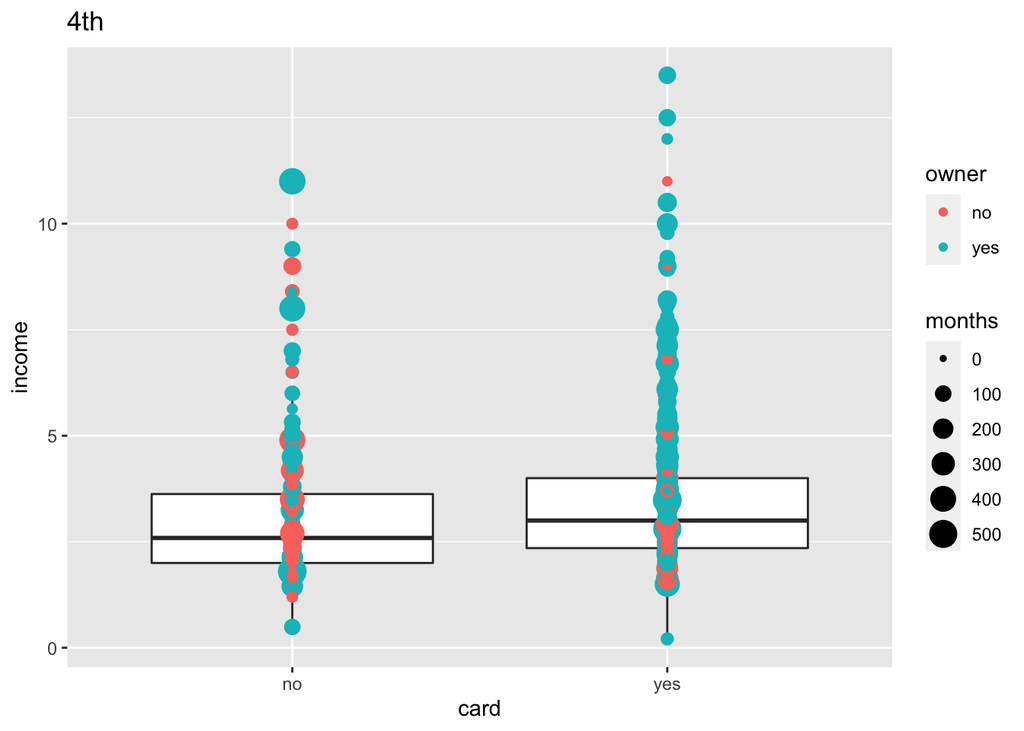

```r
# INFERENCE: We can see that the income for cards approved and rejected as a box plot. There are a number of outliers in both scenarios but none of them are below the lower bound or the minimum.
ggplot(data=data, aes(x=card, y=income))+geom_boxplot()+geom_point(aes(size=months, colour=owner)) + labs(title = "4th")
```

```r
# INFERENCE: We can see the same with respect to whether or not the user is a owner and how long he has been living in the area. The months of living does not seem to posses a pattern from the initial observation. However, the owner or not, from the initial glance, we see that there is more blue points in yes category than in no. This suggests that it is more likely to get your card approeved if you are an owner.
```

##### 5) Visualise the box plot of the income and infer statistics

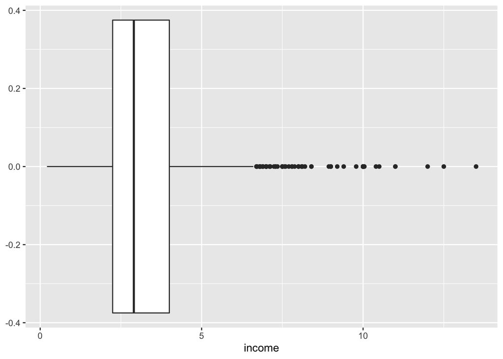

```r
ggplot(data, aes(income)) + geom_boxplot()
```

INFERENCE: The median line in the box is closer to the 25th percentile than it is to the 75th. The lower bound is close to 0 and there are numerous outliers as shown on the right. This also supports the claim of q1 as the median is towards the left.